# Protein Folding Problem

Naymul Hossain

December 11, 2020

$\newline$ **Exploratory Analysis of Dataset:**$\newline$ Initially I started off playing with the data by gathering some variables, and also angles, since it seemed unique compared to others. I found out that there is a trend for angles when the scatterplot is observed. The plot below shows some randomly picked variables and angles to understand the dataset. $\newline$ What I found out was there were many variables which has no relation with accuracy(such as the $2^{nd}$ to $4^{th}$ scatterplots shown above. In particular, I found out that the variables *scArgN_bbC_ medshort* (column 478) and *scArgN_bbO_short* (column 483), formed exact multicollinearity. Therefore, even before I started getting rid of multicollinearity in the next section using VIF, I got rid of them from the dataset. If this was not done, I would not have been able to find the VIF, since $X^T X$ would *not* have existed

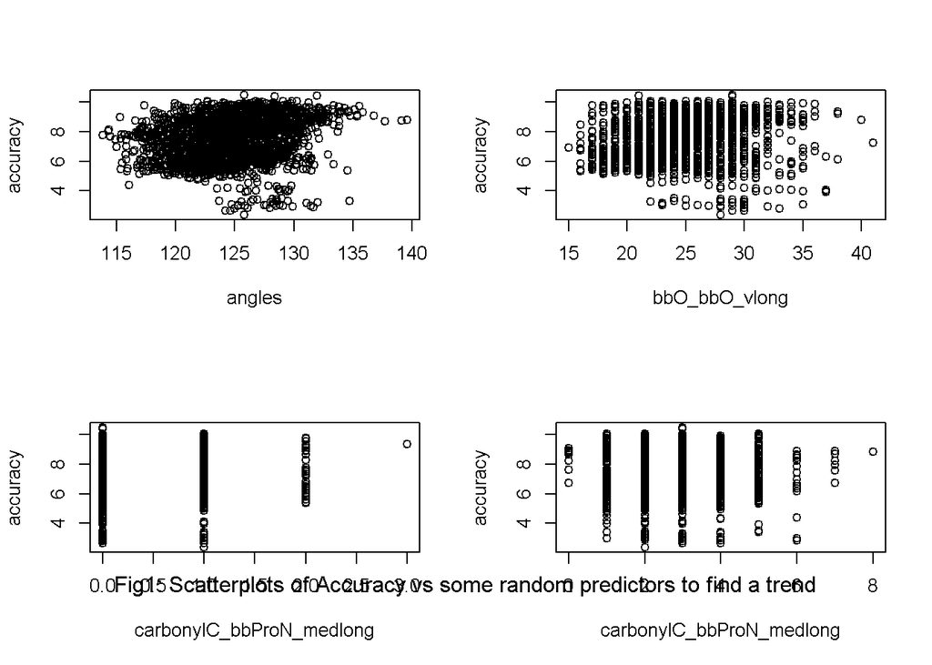

$\newline$ **Methods:**$\newline$ - *Getting rid of Multicollinearity*: Firstly, getting rid of multicollinearity was important, so as to make sure we get rid of as many predictors, which does the same contribution in building our model. Therefore, any predictor with a value $\geq 10$ was removed.So, now we have $569$ variables to work with. Reducing the number of variables also contributed in lower computation time, and also helps in interpretability of our analysis. -Going through the cross validation of 6 models, where it required more than 10 hours for one in the generic way, I decided to select model without cross validation, with the promise of training my data using $k=N$ cross validation once my model is selected. Below the $R^2_{Adj}$ for all the six models are given:

| x |
| --- |
| 0.9035353 |
| 0.9079307 |
| 0.9059144 |
| 0.8716133 |
| 0.8855601 |
| 0.8809154 |

We can understand with such high $R^2_{Adj}$ values that the models have a goodness of fit. Howver, that is not all, since now we will compare to check if the model assumptions are maintained.

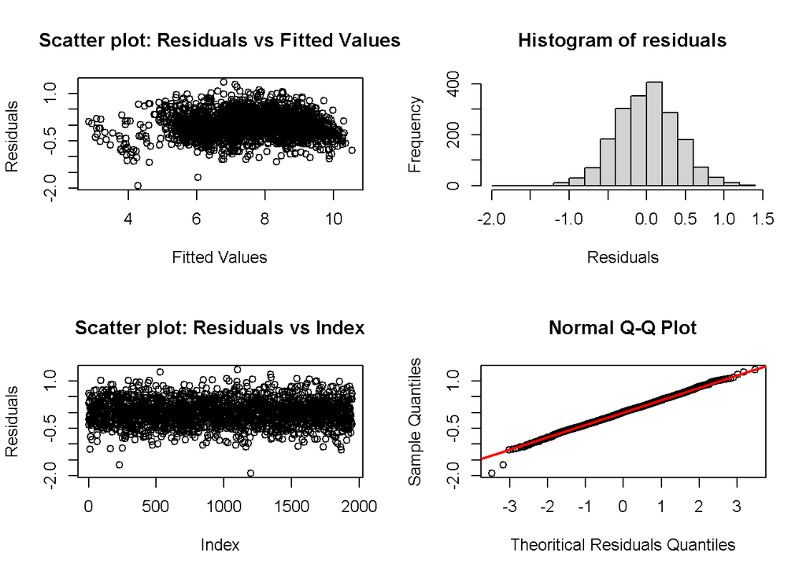

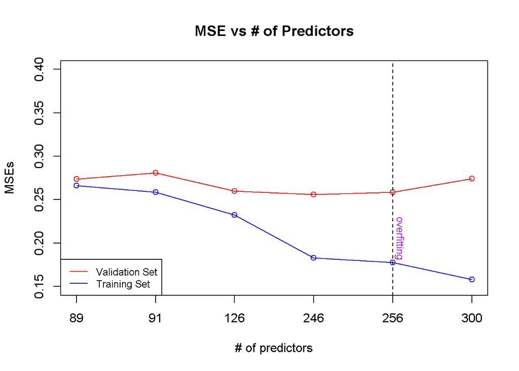

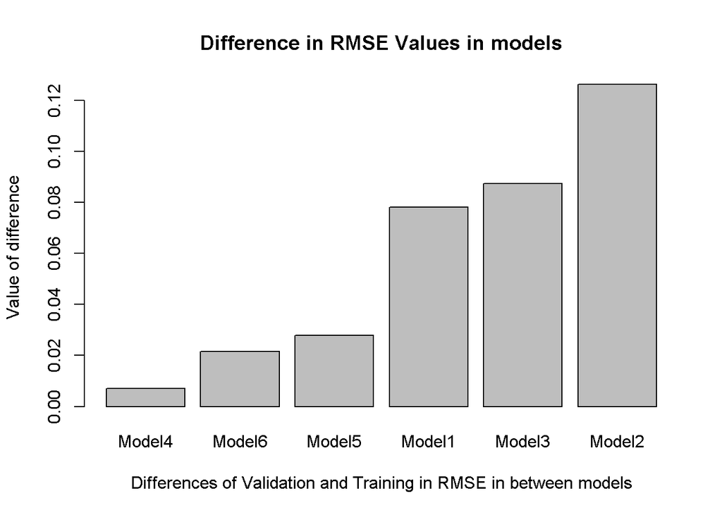

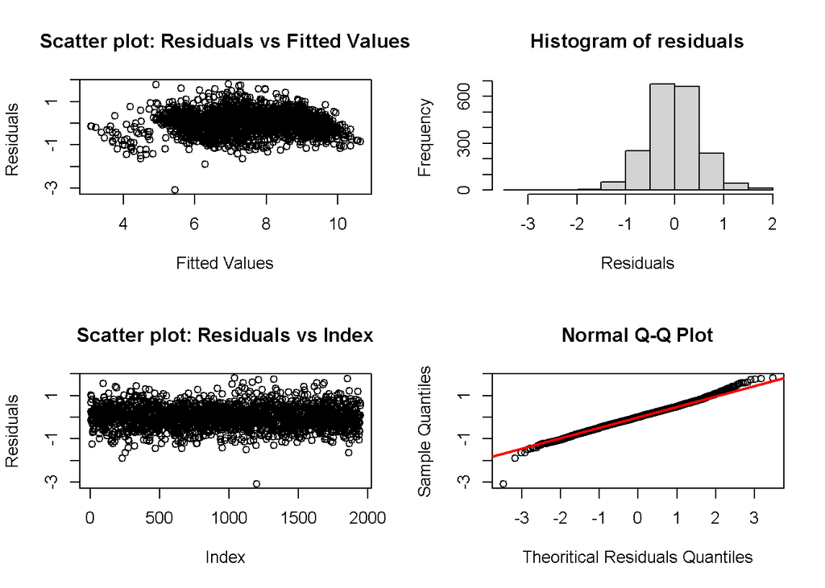

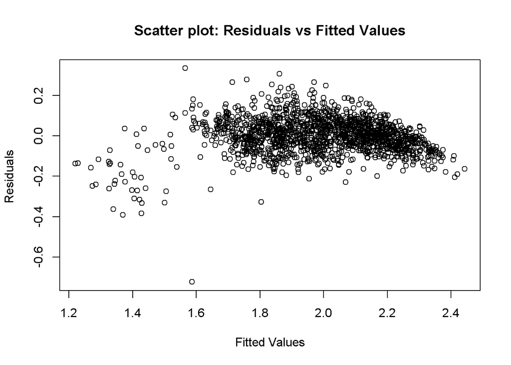

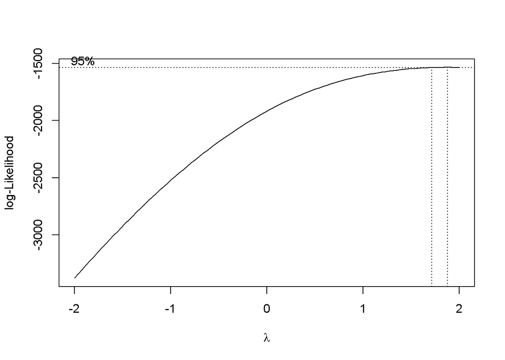

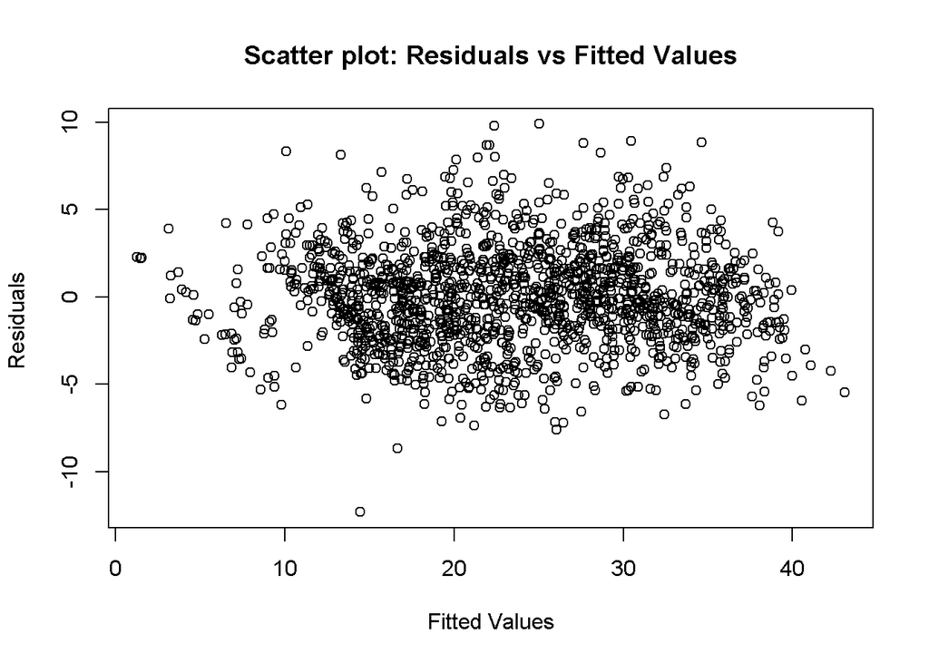

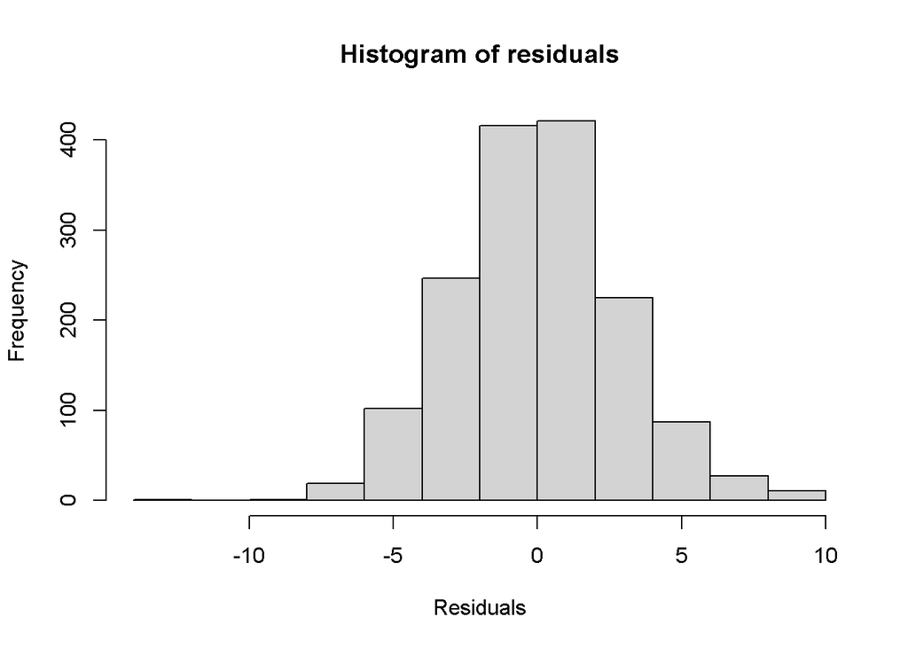

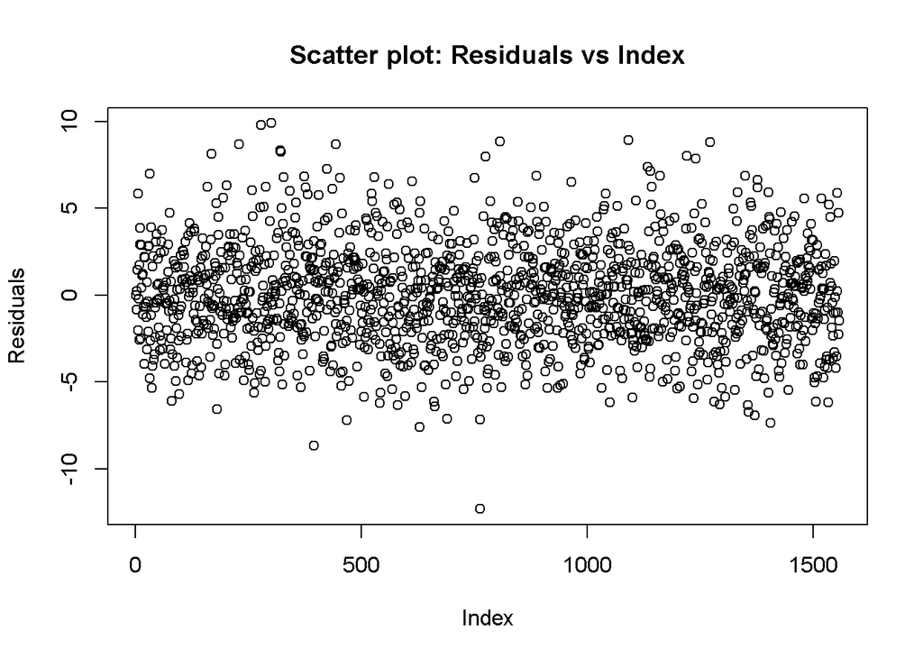

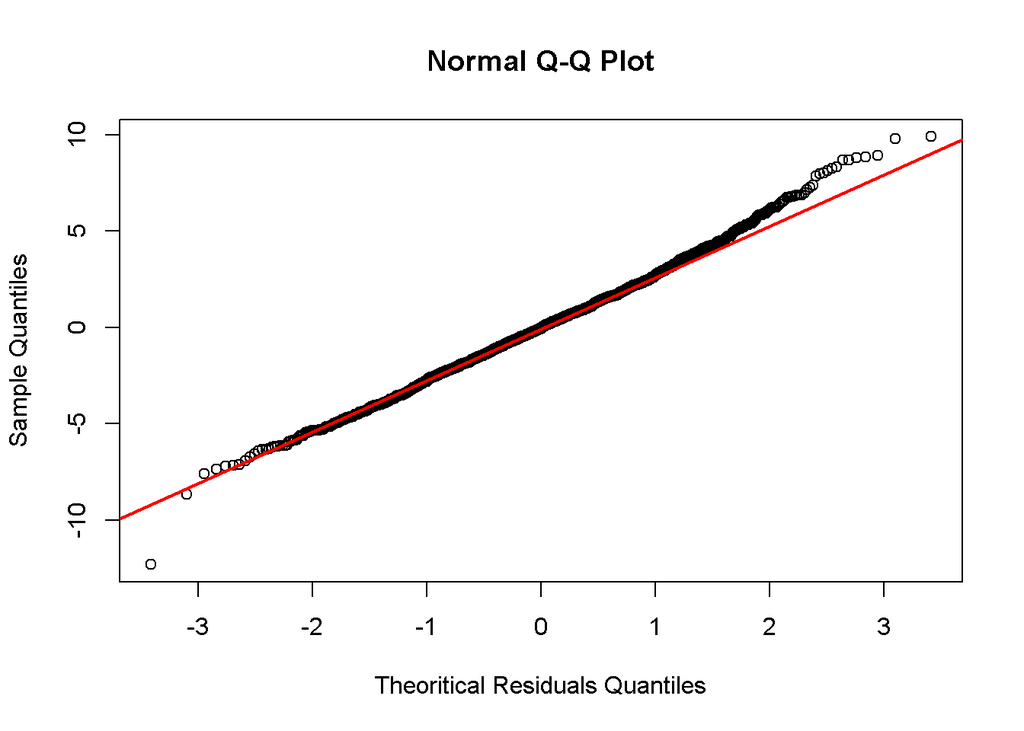

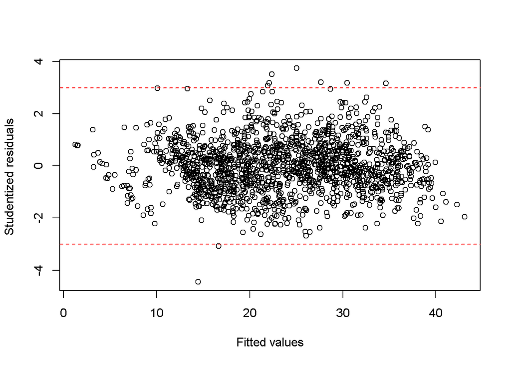